# Twitter Act Report

## Author:

### Victor Mayowa, ADELEYE (MB;BS), Google Certified Data Analyst and Udacity Scholar

- Preface
- Introduction
- Insights
- Data Visualizations
- Conclusions

## Preface

> This project is my second project as a student of ALX-Udacity Data Analytics Nanodegree scholarship programme, which is a project intensive and career-focused training programme. It is instituted to provide and hone the skills of budding data analysts. There are two reports requested:
> > - Twitter Wrangling Report
> > - Twitter Act Report

## Introduction

>

> This report is to script out certain insights gotten from the the wrangled data and communicate it via visualization

## Insights

1. There is 78% positive correlation between number of tweets retweeted and liked. This suggest that there is a strong connection between a loiked and retweeted tweet such that a tweet with a lot of likes will most likely have a lot of retweets
2. Pupper was found to be the most used among the nicknames given to dogs. Although, large percentage of the tweets did not indicate nicknames.
3. golden_retriever and Labrador_retriever are the most predicted breed from the image posted
4. Most of the tweets came from Iphone users

## Data Visualizations

#### INSIGHT 1

> - There is a strong relationship between the number of retweets and favourites of tweeest. About 78% was revelaed. this shows that a liked tweets will most likely be retweeted.
> - below is the visualization to show the correlation

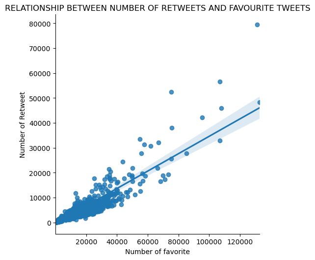

#### INSIGHT 2

>

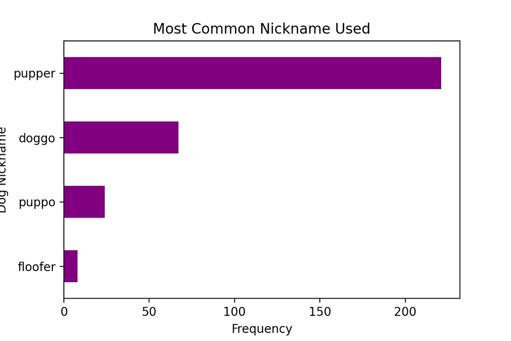

#### INSIGHT

>

> - It was found out that the most common source where tweets were posted came from Iphone users(98% of them)
> - below is piechart representing the source of tweets.

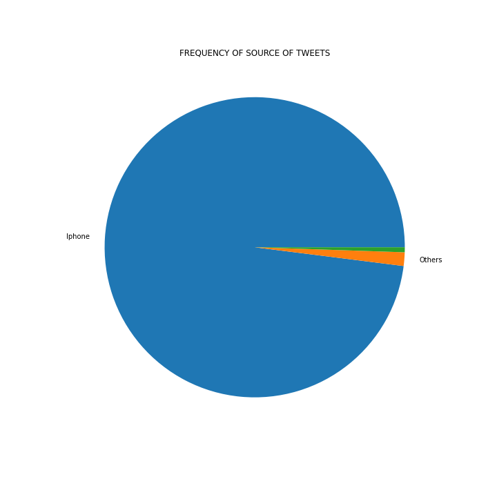

## Conclusions

- More investigation can be done to know the reason a breed is preferable or should we conclude these breeds are the most preferable among dog buyers.
- Is there a bias that should be investigated since majority of tweets came from Iphone users?
- This analysis can be used by dog merchants to know the breeds of dogs at the least popular among Iphone users